# Formatting and fitting reinfection lab data for REINF and AGE experiments

Mark Wilber

```r
library(ggplot2)
library(data.table)
library(rstan)
library(reshape2)
```

# REINF Experiment

## Step 1: Formatting data for IPM analysis

Load in the data

```r
dat = fread("../../data/lab_data/REINF_experiment_data.csv")
```

Plot the experimental data

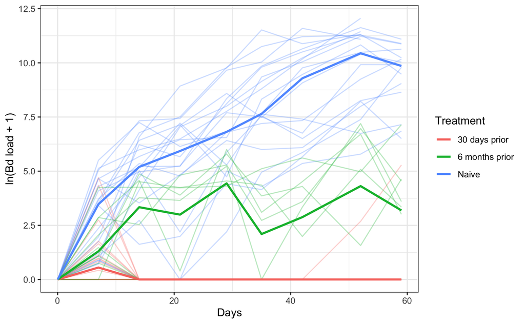

```r
# Drop preliminary days
pdat = as.data.table(dat)[days >= -17, ]
pdat[days == -17, "days"] = 0
pdat$treatment = plyr::revalue(pdat$ttt, c("A"="30 days prior", "B"="6 months prior", "N"="Naive"))

pdat_medians = pdat[, list(median_load=median(ZE)), by=list(treatment, days)]
ggplot(pdat, aes(x=days, y=log(ZE + 1), color=treatment)) + geom_line(aes(group=as.factor(frog)), alpha=0.3) +
                geom_line(data=pdat_medians, aes(y=log(median_load + 1), x=days, color=treatment), linewidth=1) +
                theme_bw() + ylab("ln(Bd load + 1)") + xlab("Days") + guides(color=guide_legend(title="Treatment"))
```

Format the data for the Stan analysis. Drop all preliminary time points before day == -17 as these were just swabs checking on individuals.

```r
# Split up the data by treatment
trun_dat = dat[dat$days >= - 17, ]
plot_dat = trun_dat
plot_dat[plot_dat$days == -17, "days"] = 0
treatments = lapply(unique(trun_dat$ttt), function(x) trun_dat[trun_dat$ttt == x, ])

max_days = 10 # Maximum number of days
max_frogs= 20 # Maximum number of frogs

# Lists to hold results
days_arrays = list()
load_arrays = list()

for(j in 1:length(treatments)){

    tdat = treatments[[j]]
    days = array(-1, dim=c(max_frogs, max_days))
    loads = array(-1, dim=c(max_frogs, max_days))

    for(i in 1:length(unique(tdat$frog))){

        frog_id = unique(tdat$frog)[i]
        temp = tdat[tdat$frog == frog_id, c("days", "ZE")]
        temp$days[temp$days == -17] = 0 # Day -17 is really day 0

        # Check if there are two zeros and drop one of the zeros
        if(sum(temp$days == 0) > 1)
            temp = temp[-1, ]

        # Exclude frog 10 with only 2 swabs post-infection
        if(length(temp$days) > 3){
            days[i, 1:length(temp$days)] = temp$days
            loads[i, 1:length(temp$days)] = temp$ZE
        } else{
          print(frog_id)
        }
    }

    days_arrays[[j]] = days
    load_arrays[[j]] = loads
}
```

```
[1] 10
```

**How many different types of transitions are in this data?**

The treatment groups are represented by the heading “ttt”, where N=naive, A=recently infected (30 days prior) and B = distantly infected (6 months prior).

```r
trans_type = function(x, method){

  n = length(x)
  x1 = x[1:(n - 1)]
  x2 = x[2:n]

  if(method == "0tonot0")
    return(sum((x1 == 0) & (x2 > 0)))
  else if(method == "0to0")
    return(sum((x1 == 0) & (x2 == 0)))
  else if(method == "not0tonot0")
    return(sum((x1 > 0) & (x2 > 0)))
  else if(method == "not0to0")
    return(sum((x1 > 0) & (x2 == 0)))
  else
    return(paste(method, "not recognized"))

}

transitions = c("0tonot0", "0to0", "not0tonot0", "not0to0")

res = list()
treat_names = unique(trun_dat$ttt)

for(trans in transitions){

  res[[trans]] = array(NA, dim=3)
  names(res[[trans]]) = treat_names

  for(j in 1:length(load_arrays)){

    tload = load_arrays[[j]]
    res[[trans]][j] = sum(apply(tload, 1, trans_type, trans))
  }
}

res
```

```
$`0tonot0`
 N  A  B
22 12 10

$`0to0`
  N   A   B
  7 120  27

$not0tonot0
  N   A   B
124   1  39

$not0to0
 N  A  B
 3 11  4
```

```r
# Number of data points contributing to likelihood
counter = 0

for(t in 1:length(load_arrays)){ # Loop over treatments
  treatment = load_arrays[[t]]

  for(f in 1:nrow(treatment)){ # Loop over frogs

    for(time in 1:ncol(treatment)){ # Loop over time steps

      if(time != 10){ # Last time step
        if(treatment[f, time] != -1 & treatment[f, time + 1] != -1){
          counter = counter + 1
        }
      }
    }
  }
}
```

## Step 2: Fit the IPM model as described in the Appendix

```r
# Fitting the stan model
stan_data = list("T"=3, "H"= max_frogs, "time_steps"=max_days, samps=load_arrays, D=counter, days=days_arrays)
```

```r
ipm_mod = stan("stan_models/reinf_ipm_model.stan", data=stan_data,
                        warmup=1000, iter=5000, chains=3, cores=3)
```

Check model convergence

```r
# Check Summary
summary_matrix = summary(ipm_mod)$summary
summary_matrix[1:18, ]
```

```
                     mean      se_mean         sd       2.5%          25%         50%         75%       97.5%
bg0            2.50816619 0.0034287340 0.35021896  1.8272379  2.272692395  2.51035379  2.74905951  3.17996487
bg1            0.77886992 0.0004197874 0.04234402  0.6974502  0.749891289  0.77880737  0.80747757  0.86155721
bg_tA          0.16924756 0.0044275934 0.62252640 -1.0391438 -0.253298271  0.17349000  0.58533627  1.38155458
bg_tB         -0.97303999 0.0015397539 0.16711460 -1.3045204 -1.083534444 -0.97200034 -0.86336333 -0.64501212
bg_tA2         0.06363263 0.0068294619 0.96428799 -1.8057033 -0.568310659  0.04962541  0.70565765  1.98014115
bg_tB2         2.57451348 0.0079415360 0.83265841  0.9432461  2.021534858  2.57332774  3.12366135  4.22878006
bl0           -0.70976630 0.0072569155 0.80033363 -2.3834610 -1.221563446 -0.69114162 -0.16046684  0.78419990
bl1           -0.82777784 0.0020888393 0.23567657 -1.3392662 -0.973734887 -0.81130684 -0.66039421 -0.41304669
bl_tA          5.27993232 0.0118862955 1.36849581  2.8887607  4.322220780  5.17453706  6.11967030  8.32629153
bl_tB          0.60988297 0.0075988539 0.90694871 -1.1616076  0.004943403  0.61284937  1.20447096  2.40519214
bt0           -3.46892959 0.0036084178 0.47523046 -4.5057059 -3.766668351 -3.43359488 -3.13397577 -2.64354081
bt_init0       4.62020597 0.0206695273 1.59489285  2.1333453  3.466450142  4.37360826  5.55689357  8.29218901
bt_tA         -4.10268888 0.0210030053 1.65288717 -7.8358324 -5.106927584 -3.88766530 -2.90844033 -1.43314107
bt_tB         -2.93540540 0.0220348082 1.78685644 -6.8134290 -4.041729734 -2.79333602 -1.70075582  0.21390921
binit0         2.34655192 0.0019052829 0.27753944  1.8044634  2.159209327  2.34605487  2.53150297  2.89035526
sigma_init     1.85018666 0.0014366173 0.20298871  1.5010920  1.706587377  1.83299035  1.97280343  2.29561615
sigma2_growth  4.99411050 0.0136029065 1.50598543  2.7001117  3.922056030  4.78559042  5.81860882  8.57105588
delta         -0.08466440 0.0002023555 0.02254518 -0.1279304 -0.100086334 -0.08497518 -0.06977645 -0.03957314
                  n_eff      Rhat
bg0           10433.060 1.0000642
bg1           10174.784 0.9999374
bg_tA         19768.790 0.9999982
bg_tB         11779.483 1.0000783
bg_tA2        19936.116 0.9998168
bg_tB2        10993.215 1.0001450
bl0           12162.924 1.0003863
bl1           12729.835 1.0000365
bl_tA         13255.432 0.9998952
bl_tB         14245.223 1.0000516
bt0           17345.025 0.9997833
bt_init0       5953.905 1.0002133
bt_tA          6193.320 1.0001768
bt_tB          6575.984 1.0002333
binit0        21219.272 0.9997886
sigma_init    19964.643 0.9999300
sigma2_growth 12256.829 0.9998572
delta         12413.018 0.9998065
```

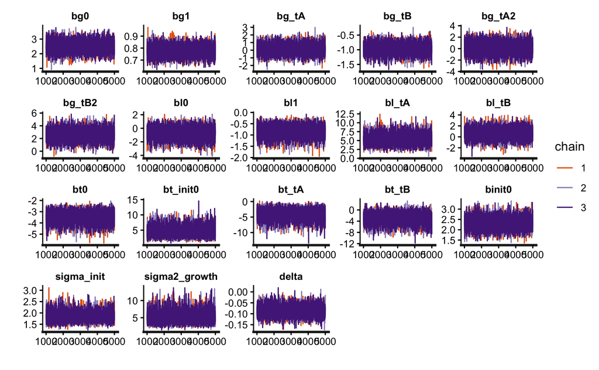

```r
traceplot(ipm_mod, pars=row.names(summary_matrix)[1:18])
```

### The initial transmission function

```r
colors = c('#1b9e77','#d95f02','#7570b3')


quants = c(0.025, 0.5, 0.975)
mod_prms = rstan::extract(ipm_mod)
naive_prob = rethinking::inv_logit(mod_prms$bt_init0)
treatA_prob = rethinking::inv_logit(mod_prms$bt_init0 + mod_prms$bt_tA)
treatB_prob = rethinking::inv_logit(mod_prms$bt_init0 + mod_prms$bt_tB)
trans_dat = melt(rbind(naive_prob, treatA_prob, treatB_prob))
colnames(trans_dat) = c("Treatment", "index", "prob")

# 1-month effect
quantile(mod_prms$bt_tA, c(0.025, 0.975))
```

```
     2.5%     97.5%
-7.835832 -1.433141
```

```r
# 6-month effect
quantile(mod_prms$bt_tB, c(0.025, 0.975))
```

```
      2.5%      97.5%
-6.8134290  0.2139092
```

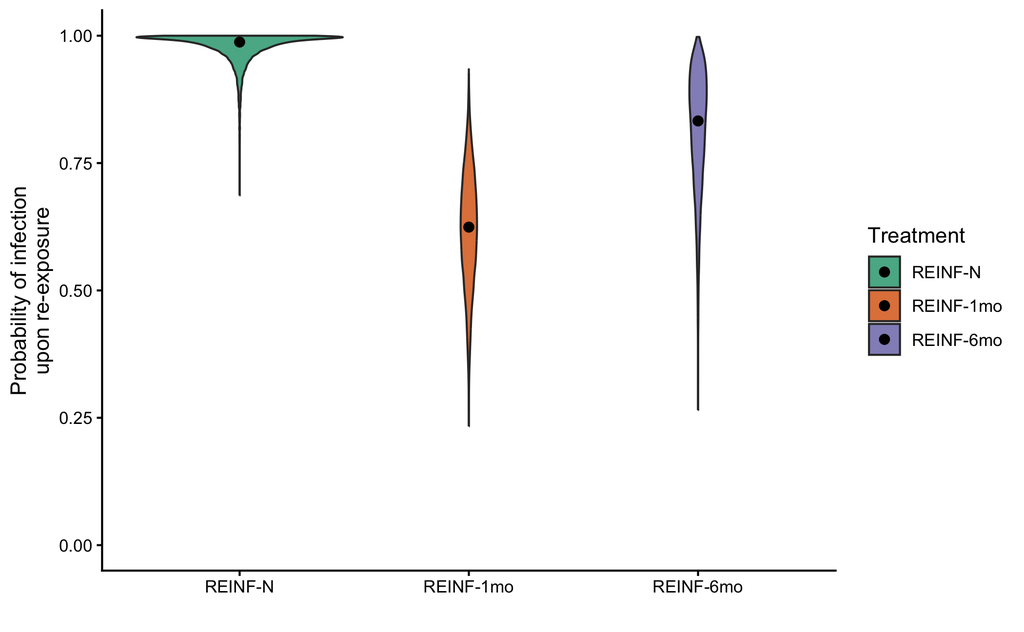

```r
trans_dat$Treatment = plyr::revalue(trans_dat$Treatment, c(naive_prob = "REINF-N", treatA_prob = "REINF-1mo", treatB_prob="REINF-6mo"))
trans_dat$Treatment = factor(trans_dat$Treatment, levels=c("REINF-N", "REINF-1mo", "REINF-6mo"))

pinf_plot = ggplot(data=trans_dat, aes(x=Treatment, y=prob, fill=Treatment)) + geom_violin(alpha=0.8) +
            xlab("") + ylab("Probability of infection\nupon re-exposure") +
            theme_classic() + stat_summary(fun.y=median, geom="point", size=2, color="black") + ylim(0, 1) + scale_fill_manual(values = colors)
pinf_plot
ggsave("../../results/initial_infection_probability_reinf.pdf", width=5, height=3)
```

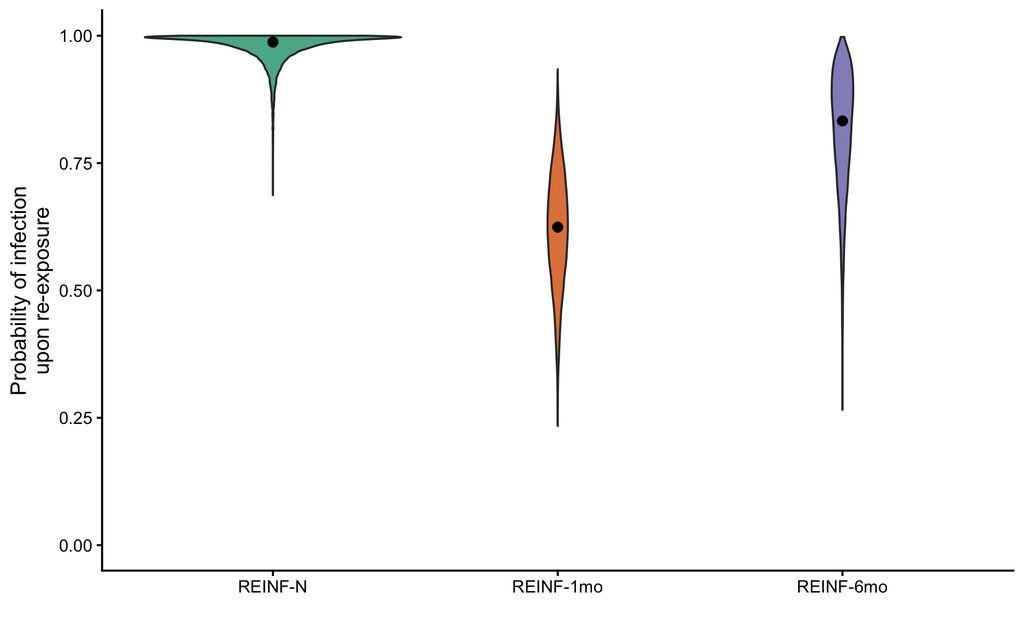

```r
pinf_plot = pinf_plot + theme(legend.position = "none")
pinf_plot
```

```r
as.data.table(trans_dat)[, list(median=quantile(prob, c(0.025, 0.5, 0.975))), by=c("Treatment")]
```

| Treatment | median |
| --- | --- |
| REINF-N | 0.8941022 |
| REINF-N | 0.9875513 |
| REINF-N | 0.9997496 |
| REINF-1mo | 0.3893379 |
| REINF-1mo | 0.6242775 |
| REINF-1mo | 0.8222126 |
| REINF-6mo | 0.5402455 |
| REINF-6mo | 0.8327405 |
| REINF-6mo | 0.9745326 |

### The loss of infection function

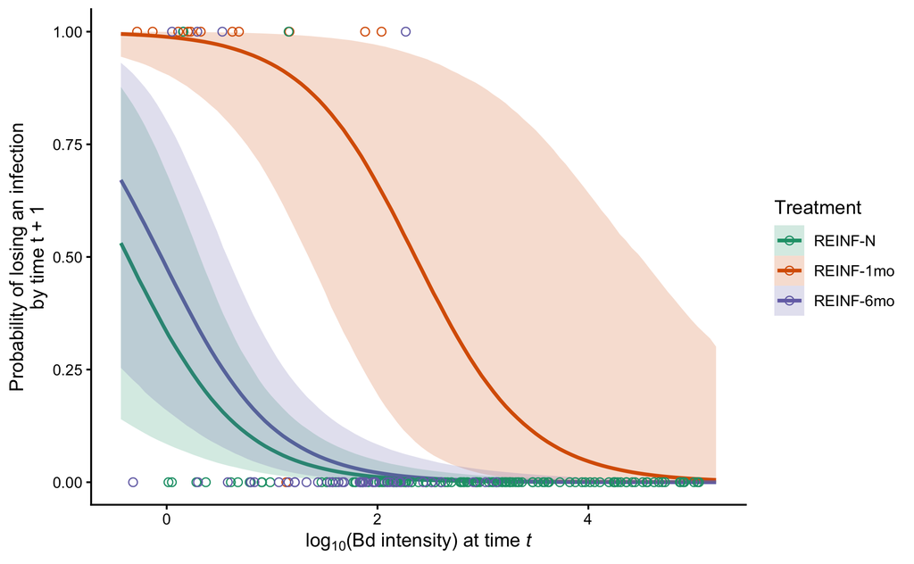

```r
library(magrittr)
zvals = seq(-1, 12, length=100)
naive_loss = sapply(zvals, function(z) rethinking::inv_logit(mod_prms$bl0 + mod_prms$bl1*z)) %>% apply(2, quantile, quants) %>% t() %>% as.data.frame()
treatA_loss = sapply(zvals, function(z) rethinking::inv_logit(mod_prms$bl0 + (mod_prms$bl1)*z + mod_prms$bl_tA)) %>% apply(2, quantile, quants) %>% t() %>% as.data.frame()
treatB_loss = sapply(zvals, function(z) rethinking::inv_logit(mod_prms$bl0 + (mod_prms$bl1)*z + mod_prms$bl_tB)) %>% apply(2, quantile, quants) %>% t() %>% as.data.frame()

naive_loss$treatment = "REINF-N"
treatA_loss$treatment = "REINF-1mo"
treatB_loss$treatment = "REINF-6mo"

loss_dat = rbind(naive_loss, treatA_loss, treatB_loss)
loss_dat$treatment = factor(loss_dat$treatment, levels=c("REINF-N", "REINF-1mo", "REINF-6mo"))

loss_dat$lgzoo = log10(exp(rep(zvals, 3)))
colnames(loss_dat) = c("lower", "median", "upper", "Treatment", "lgzoo")
loss_plot = ggplot(loss_dat) + geom_line(aes(x=lgzoo, y=median, color=Treatment), size=1) +
        geom_ribbon(aes(x=lgzoo, ymax=upper, ymin=lower, fill=Treatment),
                    alpha=0.2, size=0) + scale_fill_manual(values = colors) +
        theme_classic() +
        xlab(expression(log[10]*"(Bd intensity) at time "*italic(t))) +
        ylab("Probability of losing an infection\nby time t + 1")

# Plot observed growth data on this plot as well
loss_dat_reinf = pdat[, list(sizeZE=ZE[1:(length(ZE) - 1)],
                     sizeZENext=ZE[2:length(ZE)],
                     ttt=unique(ttt)), by=c("frog")]

loss_dat_reinf$ttt = plyr::revalue(loss_dat_reinf$ttt, c('N'="REINF-N", "B"="REINF-6mo", "A"="REINF-1mo"))
loss_dat_reinf$ttt = factor(loss_dat_reinf$ttt, levels=c("REINF-N", "REINF-1mo", "REINF-6mo"))
loss_plot = loss_plot + geom_point(data=loss_dat_reinf[sizeZE > 0, ], aes(x=log10(sizeZE), y=as.integer(sizeZENext == 0), color=ttt), size=2, pch=21) +
            scale_color_manual(values =colors)
loss_plot
ggsave("../../results/loss_plot_reinf.pdf",width=5, height=3)
```

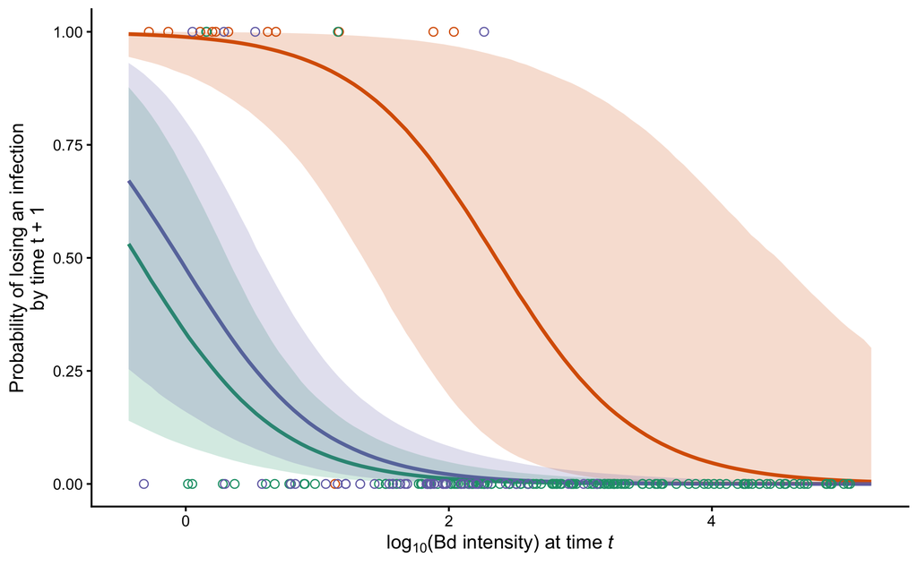

```r
loss_plot = loss_plot + theme(legend.position = "none")
loss_plot
```

### Growth of infection

```r
zvals = seq(-1, 12, length=100)
naive_loss = sapply(zvals, function(z) mod_prms$bg0 + z*(mod_prms$bg1)) %>% apply(2, quantile, quants) %>% t() %>% as.data.frame()
treatA_loss = sapply(zvals, function(z) mod_prms$bg0 + z*(mod_prms$bg1 + mod_prms$bg_tA) + mod_prms$bg_tA2
                     ) %>% apply(2, quantile, quants) %>% t() %>% as.data.frame()
treatB_loss = sapply(zvals, function(z) mod_prms$bg0 + z*(mod_prms$bg1 + mod_prms$bg_tB) + mod_prms$bg_tB2
                     ) %>% apply(2, quantile, quants) %>% t() %>% as.data.frame()

quantile(mod_prms$bg_tB, c(0.025, 0.5, 0.975))
```

```
      2.5%        50%      97.5%
-1.3045204 -0.9720003 -0.6450121
```

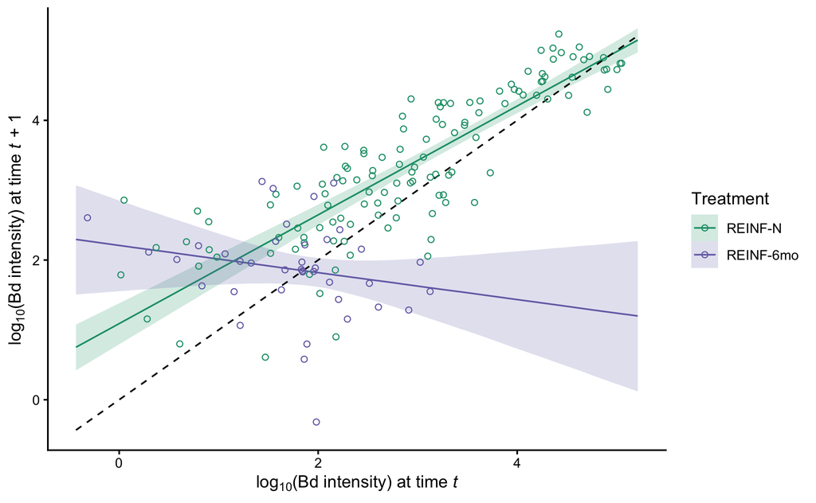

```r
naive_loss$treatment = "REINF-N"
treatA_loss$treatment = "REINF-1mo"
treatB_loss$treatment = "REINF-6mo"

growth_dat = rbind(naive_loss, treatA_loss, treatB_loss)
growth_dat$treatment = factor(growth_dat$treatment, levels=c("REINF-N", "REINF-1mo", "REINF-6mo"))
growth_dat$lgzoo = log10(exp(rep(zvals, 3)))

#Drop treatment A because there is no information to infer this
colnames(growth_dat) = c("lower", "median", "upper", "Treatment", "lgzoo")
growth_dat_trun = droplevels(growth_dat[growth_dat$Treatment != "REINF-1mo", ])

growthplot = ggplot(data=growth_dat_trun) + geom_line(aes(x=lgzoo, y=log10(exp(median)), color=Treatment)) +
        geom_ribbon(aes(x=lgzoo, ymax=log10(exp(upper)), ymin=log10(exp(lower)), fill=Treatment), alpha=0.2, size=0) +
        scale_fill_manual(values = c('#1b9e77','#7570b3')) +
        theme_classic() + xlab(expression(log[10]*"(Bd intensity) at time "*italic(t))) +
        ylab(expression(log[10]*"(Bd intensity) at time "*italic(t)*" + 1")) +
        geom_line(data=as.data.frame(zvals), aes(x=log10(exp(zvals)), y=log10(exp(zvals))), color="black", linetype="dashed")

# Plot observed growth data on this plot as well
growth_dat_reinf = pdat[, list(sizeZE=ZE[1:(length(ZE) - 1)],
                     sizeZENext=ZE[2:length(ZE)],
                     ttt=unique(ttt)), by=c("frog")]

growth_dat_reinf$ttt = plyr::revalue(growth_dat_reinf$ttt, c('N'="REINF-N", "B"="REINF-6mo", "A"="REINF-1mo"))
growth_dat_reinf$ttt = factor(growth_dat_reinf$ttt, levels=c("REINF-N", "REINF-1mo", "REINF-6mo"))

growth_plot = growthplot + geom_point(data=droplevels(growth_dat_reinf[(sizeZE > 0 & sizeZENext > 0) & (ttt != "REINF-1mo"), ]), aes(x=log10(sizeZE), y=log10(sizeZENext), color=ttt), pch=21) + scale_color_manual(values = c('#1b9e77','#7570b3'))

growth_plot
ggsave("../../results/growth_plot_reinf.pdf", width=5, height=3)
```

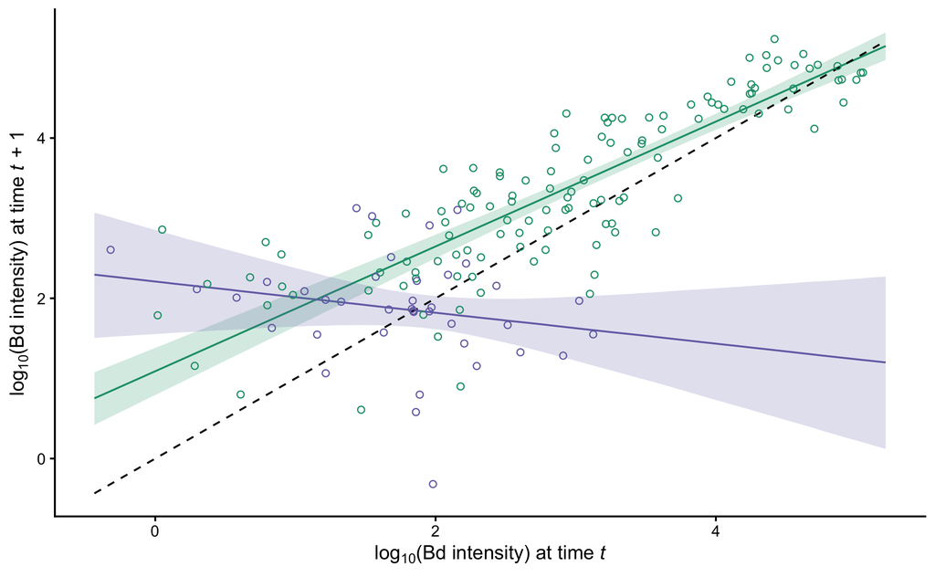

```r
growth_plot = growth_plot + theme(legend.position = "none")
growth_plot
```

### Get the statistics from the REINF model

```r
# 1. Loss effects
rethinking::precis(ipm_mod, prob=0.95)
```

```
                mean   sd   2.5%  97.5% n_eff Rhat4
bg0             2.51 0.35   1.83   3.18 10433     1
bg1             0.78 0.04   0.70   0.86 10175     1
bg_tA           0.17 0.62  -1.04   1.38 19769     1
bg_tB          -0.97 0.17  -1.30  -0.65 11779     1
bg_tA2          0.06 0.96  -1.81   1.98 19936     1
bg_tB2          2.57 0.83   0.94   4.23 10993     1
bl0            -0.71 0.80  -2.38   0.78 12163     1
bl1            -0.83 0.24  -1.34  -0.41 12730     1
bl_tA           5.28 1.37   2.89   8.33 13255     1
bl_tB           0.61 0.91  -1.16   2.41 14245     1
bt0            -3.47 0.48  -4.51  -2.64 17345     1
bt_init0        4.62 1.59   2.13   8.29  5954     1
bt_tA          -4.10 1.65  -7.84  -1.43  6193     1
bt_tB          -2.94 1.79  -6.81   0.21  6576     1
binit0          2.35 0.28   1.80   2.89 21219     1
sigma_init      1.85 0.20   1.50   2.30 19965     1
sigma2_growth   4.99 1.51   2.70   8.57 12257     1
delta          -0.08 0.02  -0.13  -0.04 12413     1
counter       380.00 0.00 380.00 380.00   NaN   NaN
prob_inf        0.81 0.12   0.54   0.97 13452     1
mean_init_inf   2.35 0.28   1.80   2.89 21219     1
mean_growth     4.82 0.56   3.71   5.93 13854     1
loss_prob       0.25 0.11   0.07   0.50 15402     1
power_sd        1.97 0.24   1.55   2.48 12531     1
```

```r
# 2. Stationary load
params = rstan::extract(ipm_mod)
treatB_stationary = (params$bg0 + params$bg_tB2) / (1 - (params$bg1 + params$bg_tB))
naive_stationary = (params$bg0) / (1 - (params$bg1))
quantile(log10(exp(naive_stationary)), c(0.025, .5, .975))
```

```
    2.5%      50%    97.5%
4.381422 4.927786 5.949749
```

```r
quantile(log10(exp(treatB_stationary)), c(0.025, .5, .975))
```

```
    2.5%      50%    97.5%
1.659425 1.849197 2.025542
```

```r
diff_btwn = log10(exp(treatB_stationary)) - log10(exp(naive_stationary))
mean(diff_btwn)
```

```
[1] -3.142637
```

```r
quantile(diff_btwn, c(.025, 0.975))
```

```
     2.5%     97.5%
-4.126501 -2.497466
```

## Step 3: Project the best fit model forward for each treatment

Now we want to project these best fit models forward in time to compare their fit to the observed data.

```r
ipm_sim_base = function(num, time_steps, params, treatment){
  # Simulating an individual frog trajectory from the fitted model (based on model ipm_mod8D)
  #
  # num : int, a simulation number
  # time_steps : number of discrete time steps to simulate the model
  # params: A vector of ipm parameters
  # treatment: Either "naive", "A", or "B"

  times = 0:time_steps
  init_load = 0
  loads = array(NA, dim=length(times))

  # Set treatment coeffs
  if(treatment == "naive"){
    treat_coefs = c(0, 0)
  } else if(treatment == "A"){
    treat_coefs = c(1, 0)
  } else{
    treat_coefs = c(0, 1)
  }

  loads[1] = init_load

  for(i in 2:(time_steps + 1)){

    current_load = loads[i - 1]

    # Transmission
    if(current_load == 0){

      if(i == 2)
        trans = rbinom(1, 1, rethinking::inv_logit(params['bt_init0'] + params['bt_tA']*treat_coefs[1] + params['bt_tB']*treat_coefs[2]))
      else
        trans = rbinom(1, 1, rethinking::inv_logit(params['bt0']))

      next_load = trans * exp(rnorm(1, mean=params['binit0'], sd=params['sigma_init']))

    } else if(current_load > 0){ # Loss of infection or growth

      loss = rbinom(1, 1, rethinking::inv_logit(params['bl0'] + params['bl1']*log(current_load) + params['bl_tA']*treat_coefs[1] +
                                          params['bl_tB']*treat_coefs[2]))
      next_load = (1  - loss) * exp(rnorm(1, mean=params['bg0'] + log(current_load)*(params['bg1'] +
                                          params['bg_tB']*treat_coefs[1] + params['bg_tB']*treat_coefs[2]) + params['bg_tB2']*treat_coefs[1] + params['bg_tB2']*treat_coefs[2]
                                          , sd=sqrt(params['sigma2_growth']*exp(2*params['delta']*log(current_load)))))

    }

    loads[i] = next_load

  }

  return(cbind(loads=loads, time=times, simid=rep(num, length(loads))))

}
```

**Naive individuals**

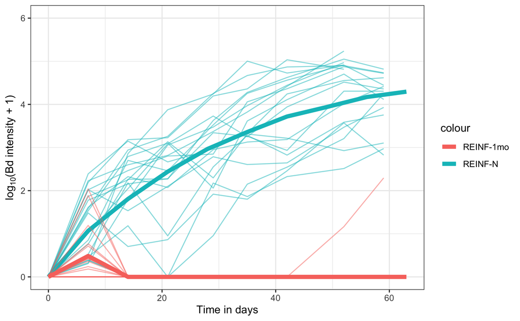

```r
all_params = as.data.frame(mod_prms[names(mod_prms)[1:18]])
med_params = apply(all_params, 2, quantile, 0.5)

traj = do.call(rbind, lapply(1:1000, function(i) ipm_sim_base(i, 9, med_params, "naive"))) %>% as.data.frame()
traj_med = as.data.frame(as.data.table(traj)[, list(med_load=median(loads),
                                                    lower=quantile(loads, 0.025),
                                                    upper=quantile(loads, 0.975)), by=c("time")])

# Naive
naive_plt = ggplot() +
          geom_line(data=plot_dat[plot_dat$ttt == "N", ], aes(x=days, y=log10(ZE + 1), group=as.factor(frog), color='REINF-N'), alpha=0.5) +
          geom_line(data=traj_med, aes(x=time*7, y=log10(med_load + 1), color='REINF-N'), size=2) +
          theme_bw() + xlab("Time in days") + ylab(expression(log[10]*"(Bd intensity + 1)")) + ylim(0, 6)


# REINF-1mo
all_params = as.data.frame(mod_prms[names(mod_prms)[1:18]])
med_params = apply(all_params, 2, quantile, 0.5)

traj = do.call(rbind, lapply(1:1000, function(i) ipm_sim_base(i, 9, med_params, "A"))) %>% as.data.frame()
traj_med = as.data.frame(as.data.table(traj)[, list(med_load=median(loads)), by=c("time")])

naive_plt = naive_plt + geom_line(data=plot_dat[plot_dat$ttt == "A", ], aes(x=days, y=log10(ZE + 1), group=as.factor(frog), color="REINF-1mo"), alpha=0.5) +
          geom_line(data=traj_med, aes(x=time*7, y=log10(med_load + 1), color='REINF-1mo'), size=2) +
          theme_bw()

naive_plt
```

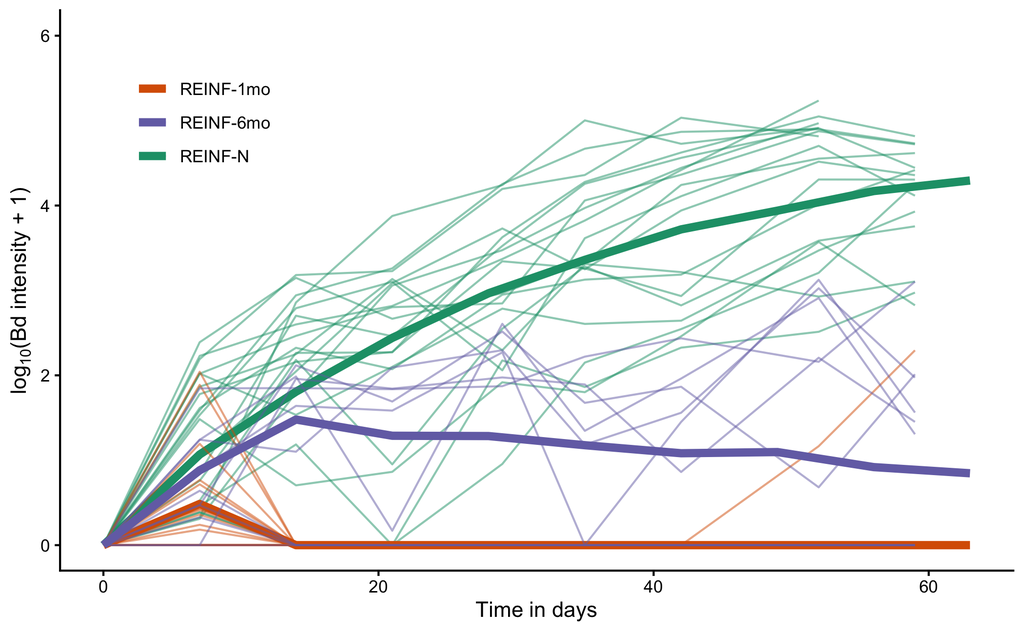

```r
# REINF-6mo
all_params = as.data.frame(mod_prms[names(mod_prms)[1:18]])
med_params = apply(all_params, 2, quantile, 0.5)

traj = do.call(rbind, lapply(1:1000, function(i) ipm_sim_base(i, 9, med_params, "B"))) %>% as.data.frame()
traj_med = as.data.frame(as.data.table(traj)[, list(med_load=median(loads)), by=c("time")])

naive_plt = naive_plt + geom_line(data=plot_dat[plot_dat$ttt == "B", ],
                                  aes(x=days, y=log10(ZE + 1),
                                      group=as.factor(frog),
                                      color="REINF-6mo"), alpha=0.5) +
                        geom_line(data=traj_med,
                                  aes(x=time*7, y=log10(med_load + 1),
                                      color='REINF-6mo'), size=2) +
                        scale_color_manual(values=c('#d95f02','#7570b3', '#1b9e77')) +
                        theme_classic() +
                        theme(legend.position = c(0.15, 0.8),
                              legend.title = element_blank())

naive_plt
```

**Plot everything together**

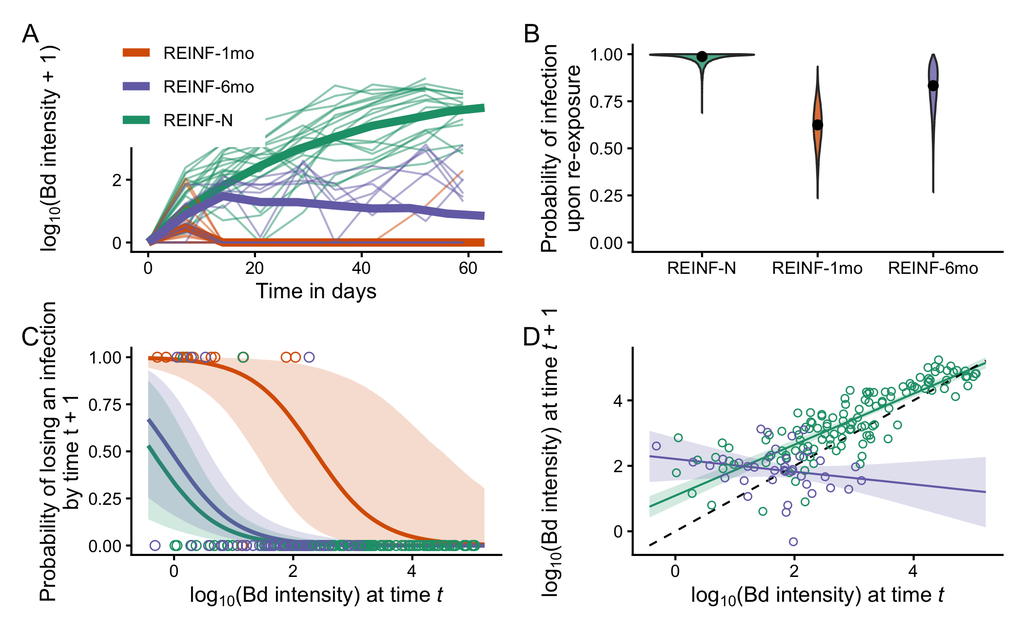

```r
library(patchwork)

naive_plt + pinf_plot + loss_plot + growth_plot + plot_layout(ncol = 2, nrow=2,) + plot_annotation(tag_levels = "A")
ggsave("../../results/combined_REINF_plots.pdf", width=12, height=7)
```

# AGE Experiment

Analysis and plotting for the AGE experiment described in the main text

```r
# Load in the zoo data
zoodat = fread("../../data/lab_data/AGE_experiment_data.csv")
```

Visualize the data by groups.

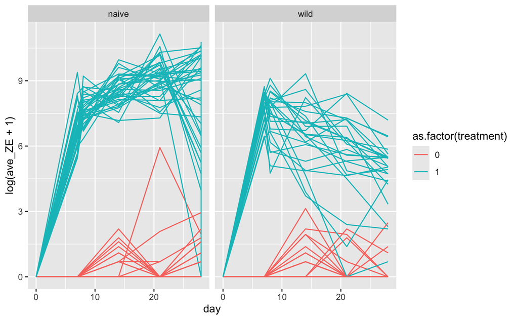

```r
ggplot(zoodat, aes(x=day, y=log(ave_ZE + 1), color=as.factor(treatment),
                   group=as.factor(frog))) +
            geom_line() + facet_wrap(~wild_or_naive)
```

```r
zoodat_dt = as.data.table(zoodat)
```

### Cleaning data

There are a number of points that need to be removed from the analysis. In particular some frogs were treated with itraconozole at different points in the analysis, and all points after the treatment need to be excluded.

```r
# Find the all days after itracon. treatment on week 1 or week 3
rm_itz_ind = ((zoodat$W1_ITCZ == 1) & (zoodat$day > 7)) | ((zoodat$W3_ITCZ == 1) & (zoodat$day > 21))
rm_itz_ind
```

```
  [1] FALSE FALSE FALSE FALSE FALSE  TRUE FALSE FALSE FALSE FALSE FALSE FALSE FALSE FALSE FALSE FALSE FALSE
 [18] FALSE FALSE FALSE FALSE FALSE FALSE FALSE  TRUE  TRUE  TRUE  TRUE FALSE FALSE FALSE FALSE FALSE FALSE
 [35] FALSE FALSE FALSE FALSE FALSE FALSE FALSE FALSE FALSE FALSE FALSE FALSE FALSE FALSE FALSE FALSE FALSE
 [52] FALSE FALSE FALSE FALSE FALSE FALSE FALSE FALSE FALSE FALSE FALSE FALSE FALSE FALSE FALSE FALSE FALSE
 [69] FALSE FALSE FALSE FALSE FALSE FALSE FALSE FALSE FALSE FALSE FALSE FALSE FALSE FALSE FALSE FALSE FALSE
 [86] FALSE FALSE FALSE FALSE FALSE FALSE FALSE FALSE FALSE FALSE FALSE FALSE FALSE FALSE FALSE FALSE FALSE
[103] FALSE FALSE FALSE FALSE FALSE FALSE  TRUE  TRUE  TRUE  TRUE FALSE FALSE FALSE FALSE FALSE FALSE FALSE
[120] FALSE FALSE FALSE FALSE FALSE FALSE FALSE FALSE FALSE FALSE FALSE FALSE FALSE FALSE FALSE FALSE FALSE
[137] FALSE FALSE FALSE FALSE FALSE FALSE FALSE FALSE FALSE FALSE FALSE FALSE FALSE FALSE FALSE FALSE FALSE
[154] FALSE FALSE FALSE FALSE FALSE FALSE FALSE FALSE FALSE FALSE FALSE FALSE FALSE FALSE FALSE FALSE FALSE
[171]  TRUE  TRUE  TRUE  TRUE FALSE FALSE FALSE FALSE FALSE FALSE FALSE FALSE FALSE FALSE FALSE FALSE  TRUE
[188]  TRUE  TRUE  TRUE FALSE FALSE FALSE FALSE FALSE FALSE FALSE FALSE FALSE FALSE FALSE FALSE FALSE FALSE
[205] FALSE FALSE FALSE FALSE FALSE FALSE FALSE FALSE FALSE FALSE  TRUE  TRUE  TRUE  TRUE FALSE FALSE FALSE
[222] FALSE FALSE FALSE FALSE FALSE FALSE FALSE FALSE FALSE  TRUE  TRUE  TRUE  TRUE FALSE FALSE  TRUE  TRUE
[239]  TRUE  TRUE FALSE FALSE FALSE FALSE FALSE FALSE FALSE FALSE FALSE FALSE FALSE FALSE  TRUE  TRUE  TRUE
```

[output cut: 18 more lines]

```r
# Remove the points where these conditions are TRUE
zoodat_noitra = zoodat_dt[!rm_itz_ind, ]

# Fix one mis-labeled point
zoodat_noitra$day[zoodat_noitra$swab_id == "Tahoe098_W0"] = 0
zoodat_noitra[tub == 17 & frog == 98,  ]
```

| swab_id | date | frog | day | ID | ave_ZE | wild_or_naive | W1_ITCZ | W3_ITCZ | control | treatment | sex | beg_wt | beg_svl | tank | tub |
| --- | --- | --- | --- | --- | --- | --- | --- | --- | --- | --- | --- | --- | --- | --- | --- |
| Tahoe098_W0 | 4/1/15 | 98 | 0 | Tahoe098 | 0 | naive | 0 | 0 | 0 | 1 | F? | 5 | 32 | 2 | 17 |
| Tahoe098_W1 | 4/7/15 | 98 | 7 | Tahoe098 | 2548 | naive | 0 | 0 | 0 | 1 | F? | 5 | 32 | 2 | 17 |
| Tahoe098_W1B | 4/8/15 | 98 | 8 | Tahoe098 | 2117 | naive | 0 | 0 | 0 | 1 | F? | 5 | 32 | 2 | 17 |
| Tahoe098_W2 | 4/14/15 | 98 | 14 | Tahoe098 | 6878 | naive | 0 | 0 | 0 | 1 | F? | 5 | 32 | 2 | 17 |
| Tahoe098_W3 | 4/21/15 | 98 | 21 | Tahoe098 | 9806 | naive | 0 | 0 | 0 | 1 | F? | 5 | 32 | 2 | 17 |
| Tahoe098_W4 | 4/28/15 | 98 | 28 | Tahoe098 | 48193 | naive | 0 | 0 | 0 | 1 | F? | 5 | 32 | 2 | 17 |

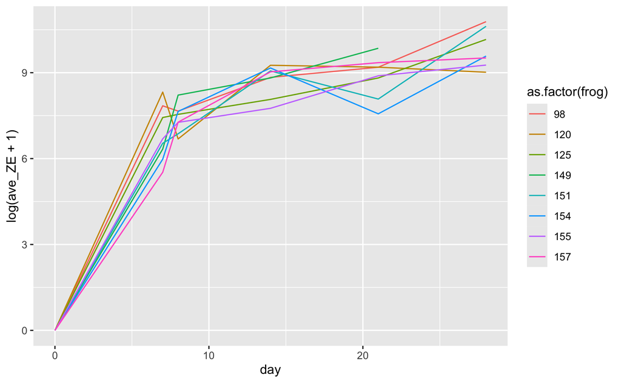

```r
ggplot(zoodat_noitra[tub == 17, ], aes(x=day, y=log(ave_ZE + 1), color=as.factor(frog))) +
            geom_line()
```

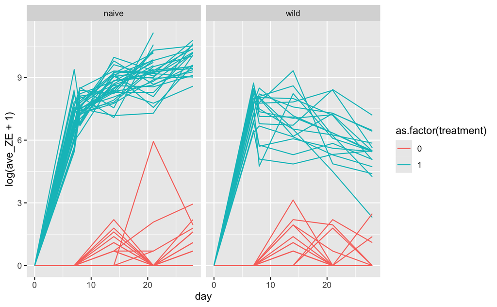

```r
ggplot(zoodat_noitra, aes(x=day, y=log(ave_ZE + 1), color=as.factor(treatment), group=as.factor(frog))) +
            geom_line() + facet_wrap(~wild_or_naive)
```

```r
# Add tub density as a covariate
zoodat_noitra = merge(zoodat_noitra, zoodat_noitra[, list(density=length(unique(frog))), by=list(tub)], by="tub")
```

Plot the cleaned data

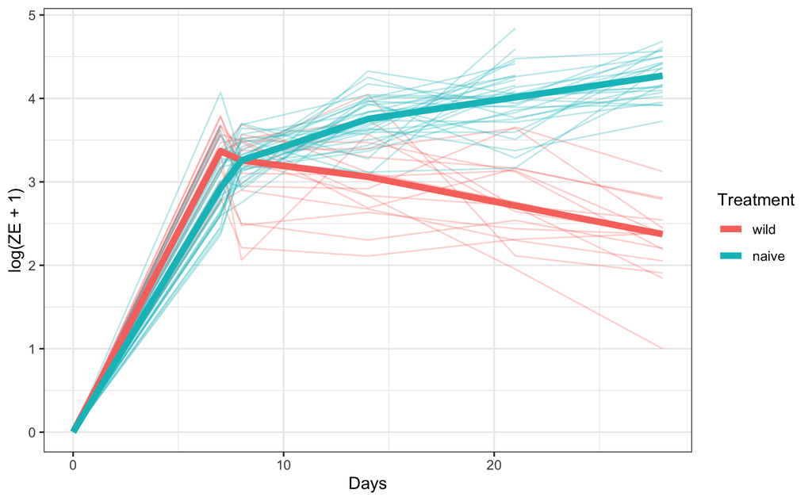

```r
zoodat_noitra$wild_or_naive = factor(zoodat_noitra$wild_or_naive, c('wild', 'naive'))
med_zoo = zoodat_noitra[treatment==1, list(med_val=quantile(ave_ZE, 0.5)), by=list(day, wild_or_naive)]

ggplot(zoodat_noitra[treatment == 1, ]) +
      geom_line(aes(x=day, y=log10(ave_ZE + 1), color=wild_or_naive, group=frog), alpha=0.3) +
      geom_line(data=med_zoo, aes(x=day, y=log10(med_val + 1), color=wild_or_naive), size=2) +
      theme_bw() + ylab("log(ZE + 1)") + xlab("Days") + guides(color=guide_legend(title="Treatment"))
```

## Set-up the model to fit the IPM

```r
# Split up the data by treatment
trun_dat = zoodat_noitra[treatment == 1]
plot_dat = trun_dat
treatments = lapply(c("naive", "wild"), function(x) trun_dat[trun_dat$wild_or_naive == x, ])

max_days = 6 # Maximum number of days
max_frogs = 35 # Maximum number of frogs

# Lists to hold results
days_arrays = list()
load_arrays = list()

for(j in 1:length(treatments)){

    tdat = treatments[[j]]
    days = array(-1, dim=c(max_frogs, max_days))
    loads = array(-1, dim=c(max_frogs, max_days))

    for(i in 1:length(unique(tdat$frog))){

        frog_id = unique(tdat$frog)[i]
        temp = tdat[tdat$frog == frog_id, .(day, ave_ZE)][order(day)]
        temp = temp[day != 8]

        days[i, 1:length(temp$day)] = temp$day
        loads[i, 1:length(temp$day)] = temp$ave_ZE

    }

    days_arrays[[j]] = days
    load_arrays[[j]] = loads
}
```

```r
days_arrays
```

```
[[1]]
      [,1] [,2] [,3] [,4] [,5] [,6]
 [1,]    0    7   14   21   -1   -1
 [2,]    0    7   14   21   28   -1
 [3,]    0    7   -1   -1   -1   -1
 [4,]    0    7   14   21   28   -1
 [5,]    0    7   14   21   -1   -1
 [6,]    0    7   14   21   28   -1
 [7,]    0    7   14   21   28   -1
 [8,]    0    7   -1   -1   -1   -1
 [9,]    0    7   14   21   28   -1
[10,]    0    7   14   21   28   -1
[11,]    0    7   14   21   28   -1
[12,]    0    7   14   21   28   -1
[13,]    0    7   14   21   28   -1
```

[output cut: 60 more lines]

```r
# Fitting the stan model
stan_data = list(T=2, H=max_frogs,
                 time_steps=max_days,
                 samps=load_arrays,
                 days=days_arrays)
```

## Fit the model

Fit the Stan model as described in the Appendix

```r
age_mod1 = stan("stan_models/age_ipm_model.stan", data=stan_data,
                        warmup=1000, iter=5000, chains=4, cores=4)
```

Check model convergence

```r
summary_matrix = summary(age_mod1)$summary
summary_matrix
```

```
                      mean      se_mean         sd         2.5%           25%           50%           75%
bg0             5.63351695 0.0069270810 0.62566029    4.3932067    5.21590558    5.63750185    6.05614990
bg1             0.43524841 0.0008587751 0.07736228    0.2849991    0.38301891    0.43470042    0.48668702
bg_tA          -0.02659797 0.0011452216 0.10261263   -0.2297594   -0.09584321   -0.02548014    0.04285735
bg_tA2         -2.23779585 0.0085710347 0.75722876   -3.7133578   -2.75285497   -2.24822086   -1.72568263
binit0          7.20128012 0.0010672630 0.12360684    6.9566704    7.11921102    7.20079116    7.28434205
sigma_init      0.95884237 0.0007980325 0.08906547    0.8034548    0.89623478    0.95227935    1.01390308
sigma_growth    0.96184763 0.0005561839 0.06094517    0.8522525    0.91880938    0.95877667    1.00085618
lp__         -271.08897357 0.0223523430 1.86169366 -275.5295283 -272.10625780 -270.78900823 -269.70239129
                    97.5%     n_eff      Rhat
bg0             6.8534210  8157.868 1.0002136
bg1             0.5886745  8115.208 1.0001233
bg_tA           0.1716518  8028.281 0.9999928
bg_tA2         -0.7412453  7805.266 1.0000168
binit0          7.4425747 13413.499 1.0000805
sigma_init      1.1535268 12455.971 1.0001070
sigma_growth    1.0902449 12007.198 1.0000851
lp__         -268.4264571  6936.978 1.0000147
```

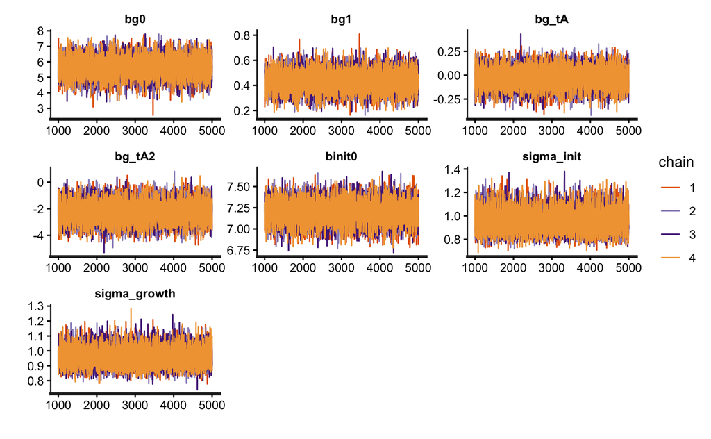

```r
traceplot(age_mod1, pars=row.names(summary_matrix)[1:7])
```

### Growth of infection

```r
mod_params = rstan::extract(age_mod1)
zvals = seq(4, 11, length=100)
naive_growth = sapply(zvals, function(z) mod_params$bg0 + z*(mod_params$bg1)) %>%
               apply(2, quantile, quants) %>%
                t() %>%
                as.data.frame()
treatA_growth = sapply(zvals, function(z) mod_params$bg0 + z*(mod_params$bg1 + mod_params$bg_tA) + mod_params$bg_tA2
                     ) %>%
                apply(2, quantile, quants) %>%
                t() %>%
                as.data.frame()

naive_growth$treatment = "AGE-N"
treatA_growth$treatment = "AGE-12mo"

growth_dat = rbind(naive_growth, treatA_growth)
growth_dat$treatment = factor(growth_dat$treatment, levels=c("AGE-N", "AGE-12mo"))
growth_dat$lgzoo = log10(exp(rep(zvals, 2)))

#Drop treatment A because there is no information to infer this
colnames(growth_dat) = c("lower", "median", "upper", "Treatment", "lgzoo")

growthplot = ggplot(data=growth_dat) +
             geom_line(aes(x=lgzoo, y=log10(exp(median)), color=Treatment)) +
             geom_ribbon(aes(x=lgzoo, ymax=log10(exp(upper)), ymin=log10(exp(lower)), fill=Treatment),
                         alpha=0.2, size=0) +
             scale_fill_manual(values = c('#1b9e77','#7570b3')) +
             scale_color_manual(values = c('#1b9e77','#7570b3')) +
             theme_classic() + xlab(expression(log[10]*"(Bd intensity) at time "*italic(t))) +
             ylab(expression(log[10]*"(Bd intensity) at time "*italic(t)*" + 1")) +
             geom_line(data=as.data.frame(zvals), aes(x=log10(exp(zvals)), y=log10(exp(zvals))),
                       color="black", linetype="dashed")

# Plot observed growth data on this plot as well
growth_dat_reinf = trun_dat[, list(sizeZE=ave_ZE[1:(length(ave_ZE) - 1)],
                              sizeZENext=ave_ZE[2:length(ave_ZE)],
                              Treatment=unique(wild_or_naive)), by=c("frog")]

growth_dat_reinf
```

| frog | sizeZE | sizeZENext | Treatment |
| --- | --- | --- | --- |
| 40 | 0 | 4208 | wild |
| 41 | 0 | 4756 | wild |
| 41 | 4756 | 2366 | wild |
| 41 | 2366 | 2507 | wild |
| 41 | 2507 | 4397 | wild |
| 41 | 4397 | 278 | wild |
| 44 | 0 | 4587 | wild |
| 44 | 4587 | 1574 | wild |
| 44 | 1574 | 1148 | wild |
| 44 | 1148 | 1364 | wild |

[output cut: 233 more lines]

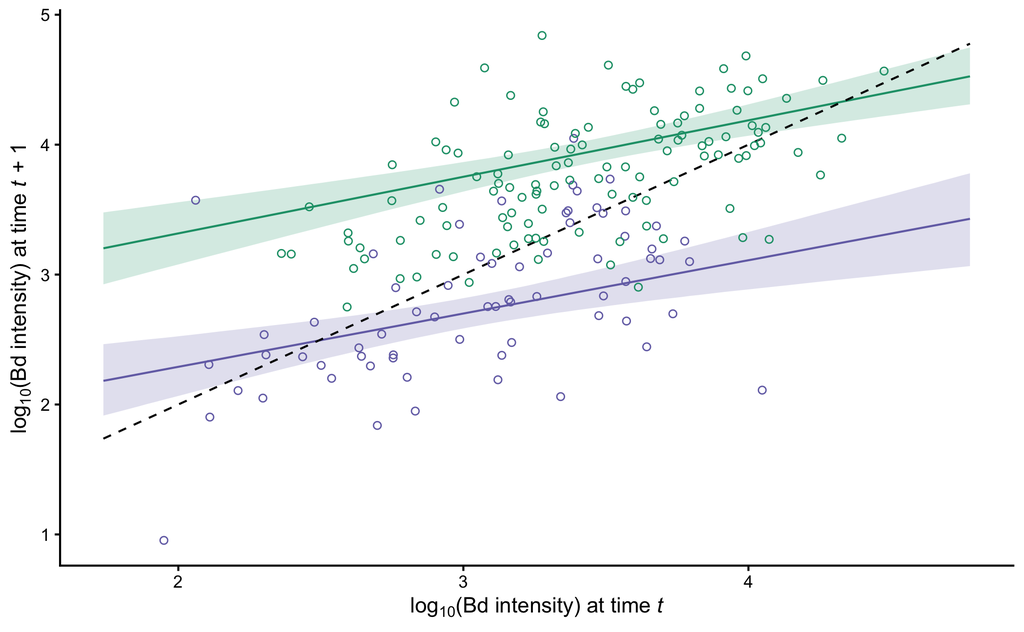

```r
growth_dat_reinf$Treatment = plyr::revalue(growth_dat_reinf$Treatment, c('wild'="AGE-12mo", "naive"="AGE-N"))
growth_dat_reinf$Treatment = factor(growth_dat_reinf$Treatment, levels=c("AGE-N", "AGE-12mo"))
#
growthplot = growthplot + geom_point(data=growth_dat_reinf[(sizeZE > 0 & sizeZENext > 0), ],
                                     aes(x=log10(sizeZE), y=log10(sizeZENext), color=Treatment), pch=21) +
                           scale_color_manual(values = c('#1b9e77','#7570b3')) + theme(legend.position = "none")
growthplot
```

### Plot the model predictions

```r
ipm_sim_age = function(num, time_steps, params, treatment){
  # Simulating an individual frog trajectory from the fitted model (based on model ipm_mod8D)
  #
  # num : int, a simulation number
  # time_steps : number of discrete time steps to simulate the model
  # params: A vector of ipm parameters
  # treatment: Either "naive" or "wild"

  times = 0:time_steps
  init_load = 0
  loads = array(NA, dim=length(times))

  # Set treatment coeffs
  if(treatment == "naive"){
    treat_coefs = 0
  } else {
    treat_coefs = 1
  }

  loads[1] = init_load

  for(i in 2:(time_steps + 1)){

    current_load = loads[i - 1]

    # Transmission
    if(current_load == 0){

      if(i == 2)
        trans = 1
      else
        trans = 1

      next_load = trans * exp(rnorm(1, mean=params['binit0'], sd=params['sigma_init']))

    } else if(current_load > 0){ # Loss of infection or growth

      loss = 0
      next_load = (1  - loss) * exp(rnorm(1, mean=params['bg0'] + params['bg_tA2']*treat_coefs +
                                                  log(current_load)*(params['bg1'] + params['bg_tA']*treat_coefs),
                                             sd=params['sigma_growth']) )

    }

    loads[i] = next_load

  }

  return(cbind(loads=loads, time=times, simid=rep(num, length(loads))))

}
```

```r
names(mod_params)
```

```
[1] "bg0"          "bg1"          "bg_tA"        "bg_tA2"       "binit0"       "sigma_init"   "sigma_growth"
[8] "lp__"
```

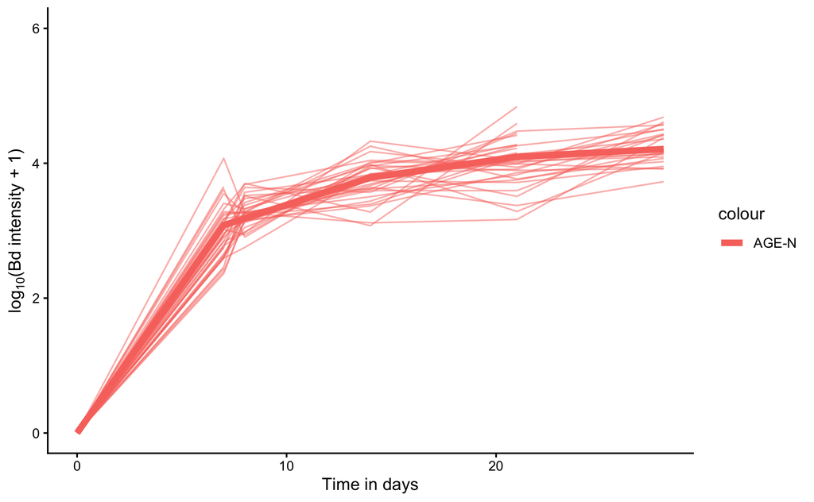

```r
all_params = as.data.frame(mod_params[names(mod_params)])[, 1:7]
med_params = apply(all_params, 2, quantile, 0.5)

traj = do.call(rbind, lapply(1:1000, function(i) ipm_sim_age(i, 4, med_params, "naive"))) %>% as.data.frame()
traj_med = as.data.frame(as.data.table(traj)[, list(med_load=median(loads),
                                                    lower=quantile(loads, 0.025),
                                                    upper=quantile(loads, 0.975)), by=c("time")])

# Naive
naive_plt = ggplot() +
          geom_line(data=plot_dat[wild_or_naive == "naive", ], aes(x=day, y=log10(ave_ZE + 1), group=as.factor(frog), color='AGE-N'), alpha=0.5) +
          geom_line(data=traj_med, aes(x=time*7, y=log10(med_load + 1), color='AGE-N'), size=2) +
          theme_classic() + xlab("Time in days") + ylab(expression(log[10]*"(Bd intensity + 1)")) + ylim(0, 6)

naive_plt
```

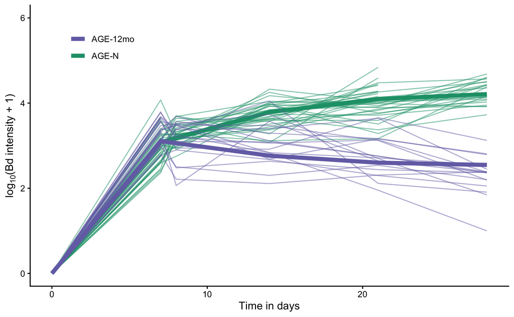

```r
# Plot Age-12mo
all_params = as.data.frame(mod_params[names(mod_params)])[, 1:7]
med_params = apply(all_params, 2, quantile, 0.5)

traj = do.call(rbind, lapply(1:1000, function(i) ipm_sim_age(i, 4, med_params, "wild"))) %>% as.data.frame()
traj_med = as.data.frame(as.data.table(traj)[, list(med_load=median(loads),
                                                    lower=quantile(loads, 0.025),
                                                    upper=quantile(loads, 0.975)), by=c("time")])

# Naive
naive_plt = naive_plt +
          # geom_line(data=traj[traj$simid < 25, ], aes(x=time*7, y=log10(loads + 1), group=simid), color="black", alpha=0.2) +
          geom_line(data=plot_dat[wild_or_naive == "wild", ], aes(x=day, y=log10(ave_ZE + 1), group=as.factor(frog), color='AGE-12mo'), alpha=0.5) +
          geom_line(data=traj_med, aes(x=time*7, y=log10(med_load + 1), color='AGE-12mo'), size=2) + scale_color_manual(values=c("#7570b3", "#1b9e77")) + theme(legend.position=c(0.15, 0.85), legend.title = element_blank())

naive_plt
```

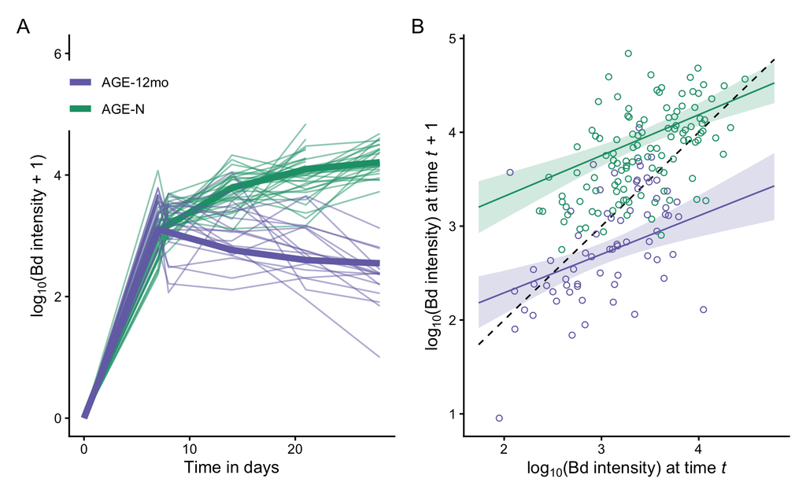

```r
naive_plt + growthplot + plot_annotation(tag_levels = "A")
ggsave("../../results/combined_AGE_plots.pdf", width=10, height=3.5)
```

### Get predicted equilibrium load

```r
naive_equil = log10(exp(mod_params$bg0 / (1 - mod_params$bg1)))
wild_equil = log10(exp((mod_params$bg0 + mod_params$bg_tA2) / (1 - (mod_params$bg1 + mod_params$bg_tA))))


quantile(wild_equil, c(0.025, 0.5, 0.975))
```

```
    2.5%      50%    97.5%
2.153968 2.492098 2.716582
```

```r
quantile(naive_equil, c(0.025, 0.5, 0.975))
```

```
    2.5%      50%    97.5%
4.101539 4.332359 4.709873
```